# Atividade em Sala - Resolução Q2

Discente Fernando Bispo, Discente Artur

28 agosto, 2021

**Relatório de desenvolvimento e resolução da Questão 02 da atividade atribuida**

# 1 Transformação dos dados

## 1.1 Importação do Banco de Dados

Com o objetivo de iniciar o tratamento do Banco de Dados (BD) é necessário a importação do mesmo em uma variável, possibilitando assim a sua manipulação.

```r
BD <- read_excel("Dados/endometriose.xls")
```

## 1.2 Identificando as variáveis.

Após o processo de importação se faz necessário a identificação e a tipagem das variáveis a fim de determinar as manipulações necessárias para possibilitar a análise desejada.

```r
BD %>% names()
```

```
##  [1] "Grupo"        "Paciente"     "Idade"        "Gestação"     "Partos"
##  [6] "Abortos"      "Dismenorréia" "Dispareunia"  "AFSr"         "CA125/A"
## [11] "CA125/B"      "PCRa"         "PCRb"
```

```r
glimpse(BD)
```

```
## Rows: 50
## Columns: 13
## $ Grupo        <chr> "Controle", "Controle", "Controle", "Controle", "Controle~
## $ Paciente     <dbl> 1, 2, 3, 4, 5, 6, 7, 8, 9, 10, 11, 12, 13, 14, 15, 1, 2, ~
## $ Idade        <dbl> 26, 37, 37, 35, 34, 38, 30, 38, 36, 41, 36, 38, 32, 37, 3~
## $ Gestação     <dbl> 3, 4, 4, 3, 4, 5, 5, 11, 7, 4, 7, 3, 3, 3, 6, 0, 0, 0, 1,~
## $ Partos       <dbl> 3, 3, 4, 3, 3, 5, 4, 7, 6, 3, 4, 3, 3, 3, 6, 0, 0, 0, 1, ~
## $ Abortos      <dbl> 0, 1, 0, 0, 1, 0, 1, 4, 1, 1, 3, 0, 0, 0, 0, 0, 0, 0, 0, ~
## $ Dismenorréia <chr> "L", "N", "N", "L", "N", "L", "N", "N", "N", "N", "N", "N~
## $ Dispareunia  <chr> "N", "P", "N", "N", "N", "N", "N", "N", "N", "N", "N", "N~
## $ AFSr         <dbl> 0, 0, 0, 0, 0, 0, 0, 0, 0, 0, 0, 0, 0, 0, 0, 1, 1, 1, 1, ~
## $ `CA125/A`    <chr> "15.9", "2.8999999999999999", "48.600000000000001", "7.20~
## $ `CA125/B`    <chr> "6.0999999999999996", "2.8999999999999999", "24", "7.9000~
## $ PCRa         <chr> "2", "<0,5", "3.2000000000000002", "2.2000000000000002", ~
## $ PCRb         <chr> "3.2000000000000002", "<0,5", "1.6000000000000001", "1.2"~
```

## 1.3 Modificação das variáveis.

Sendo variáveis categóricas ordinais faz-se necessário a mudança da categoria de texto e número para fator a fim de possibilitar sua correta utilização.

```r
BD <-
  BD %>%
    mutate(
      Dismenorréia = as_factor(Dismenorréia),
      AFSr = as_factor(AFSr)
    )
```

# 2 Resolução da Questão 2a.

## 2.1 Criação da tabela de contingência

Para a resolução da questão em seu ítem a, se faz necessário o estudo do comportamento de duas variáveis categóricas, e para que isso seja possível uma das opções é por meio da tabela de contingência ou tabela bivariada, na tentativa de identificar correlação entre as variáveis solicitadas possibilitando assim a resolução da questão.

[interactive table not shown]

Em resposta a questão, conforme exposto na tabela é possível ver que **as pacientes que doentes apresentam sim mais dor que as pacientes não doentes**, pois dentre as pacientes não doentes, aproximadamente 67% não apresentam dor enquanto que 100% das pacientes doentes apresentam dor em intensidades variadas.

A análise feita conforme descrito acima foi por meio da tabela de contingência, em virtude de estar se tratando de variáveis categóricas, no intuito de se identificar correlação entre as variáveis.

## 2.2 Questão 2b.

Obtendo medidas resumo da variável idade para pacientes dos grupos de controle e doente.

[interactive table not shown]

As idades do grupo de controle tem como média aproximadamente 35 anos, sendo que apenas 2 pessoas (13.3%) tem uma idade inferior ou igual a 30 anos.Também foi observado que a concentração de PCR em todas as pessoas do grupo controle foi inferior a 5.

Pelos dados analizados, nem todas as pessoas doentes possuem PCR superior a 5, mas todas as pessoas observadas com PCR superior a 5 eram doentes. Também houve uma tendência para o PCR acima de 5 em pessoas de idade inferior a 30 anos, sendo que, quando o PCR é superior a 10, há uma predominância ainda maior de pessoas com idade inferior a 30 anos. No grupo de controle, houve pouca representatividade de pessoas com idade inferior a 30 anos, nos levando a questionar se, com um número maior de pessoas com idade inferior a 30 anos no grupo de controle iriamos obter algum caso de PCR superior a 5.

Para análise desses dados, foi considerado os valores “<0,5” em PCR como 0,25 para facilitar a análise. Foi chegado a esse valor tirando a média entre 0 e 0,5.

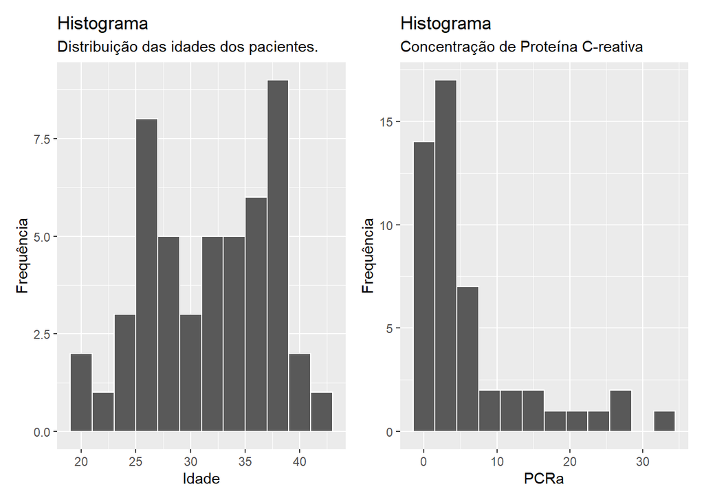

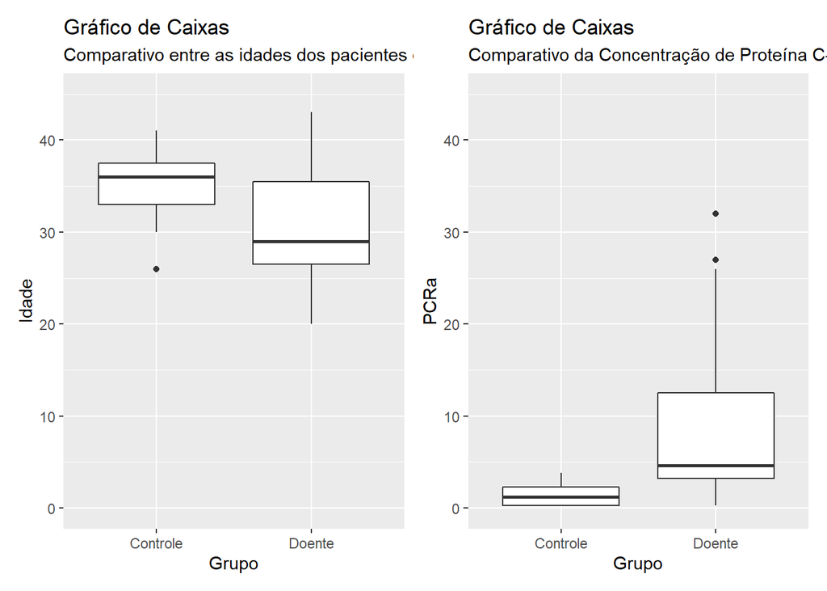

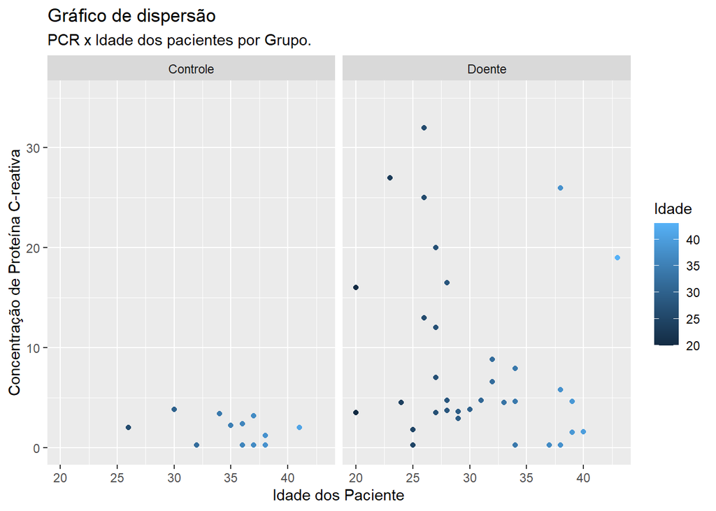

```
## [1] -0.3375552
```